# EPPS 6354 Information Management Assignment 3

Min Shi

February 19, 2022

[Personal GitHub](https://minshimia.github.io/EPPS-6354-Information-Management/)

# 1 The schema of database embedded in the online SQL interpreter (for textbook Database system concepts by Henry F. Korth Abraham) is as follows:

[figure not shown]

**SKS textbook database**

# 2 SQL codes to get a list of:

## 2.1 Students IDs (hint: from the takes relation)

```sql
select ID as student_ID
from student
```

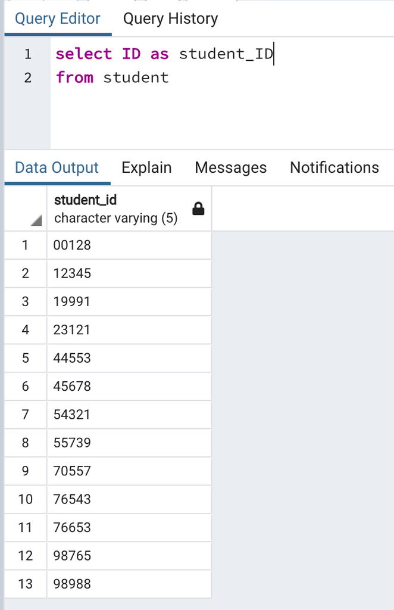

## 2.2 Instructors

```sql
select ID as instructor_ID, name
from instructor
```

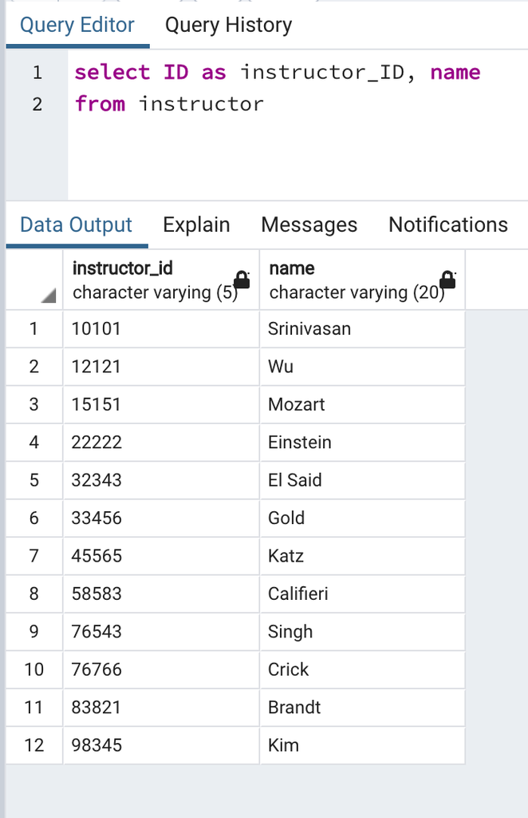

## 2.3 Departments

```sql
select dept_name
from department
```

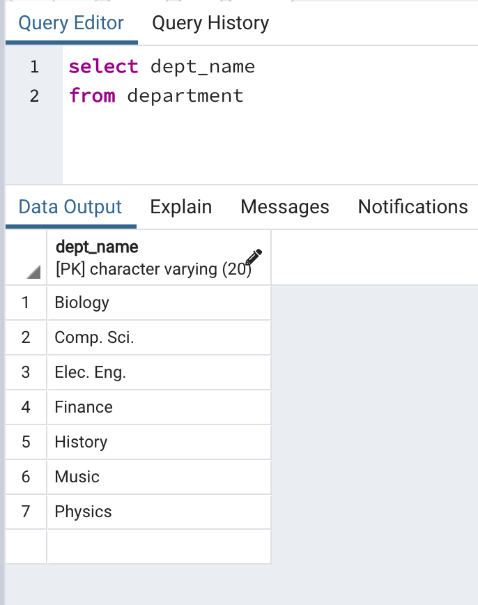

# 3 Write in SQL codes to do following queries:

## 3.1 Find the ID and name of each student who has taken at least one Comp. Sci. course; make sure there are no duplicate names in the result.

```sql
select distinct S.ID as student_ID,
                S.name,
                count(S.ID) as number_of_Comp_Sci_courses
from student S
inner join takes T
on S.ID = T.ID
inner join course C
on T.course_id = C.course_id
where C.dept_name = 'Comp. Sci.'
group by S.ID
```

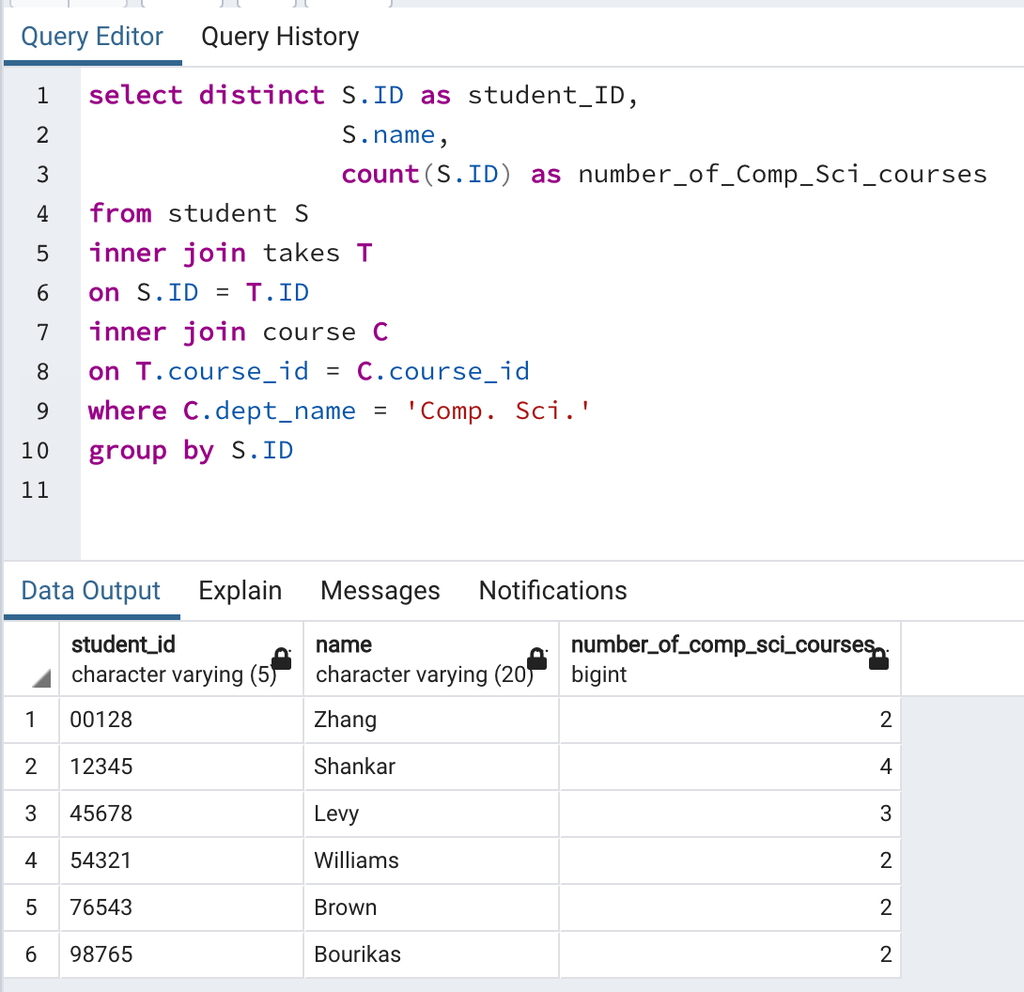

## 3.2 Add grades to the list

```sql
select distinct S.ID as student_ID,
                S.name,
                C.title,
                T.grade
from student S
inner join takes T
on S.ID = T.ID
inner join course C
on T.course_id = C.course_id
where C.dept_name = 'Comp. Sci.'
```

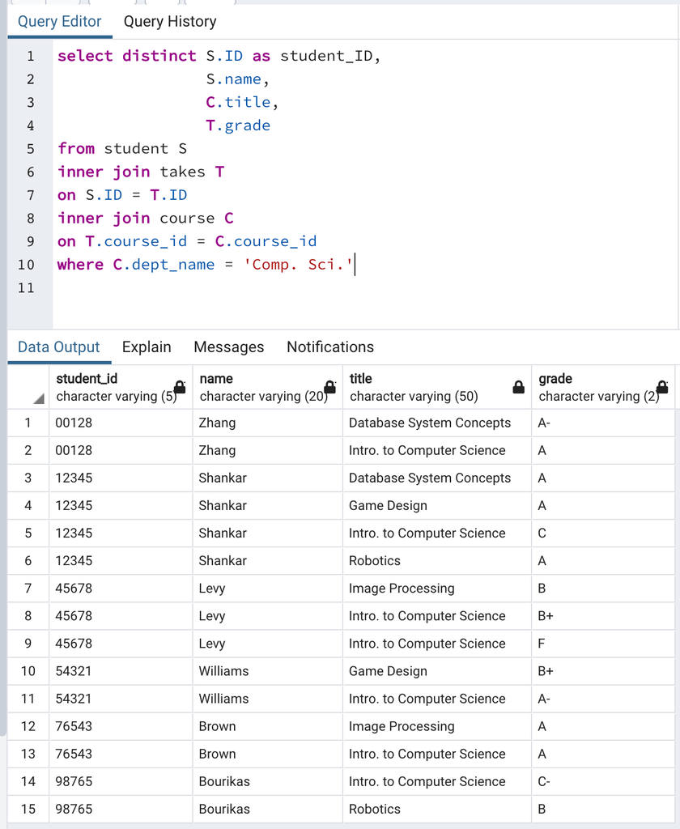

## 3.3 Find the ID and name of each student who has not taken any course offered before 2017.

```sql
select distinct s.ID as student_ID,
                s.name
from student s
where s.ID not in
(
    select distinct S.ID
    from student S
    inner join takes T
    on S.ID = T.ID
    where T.year < 2017);
```

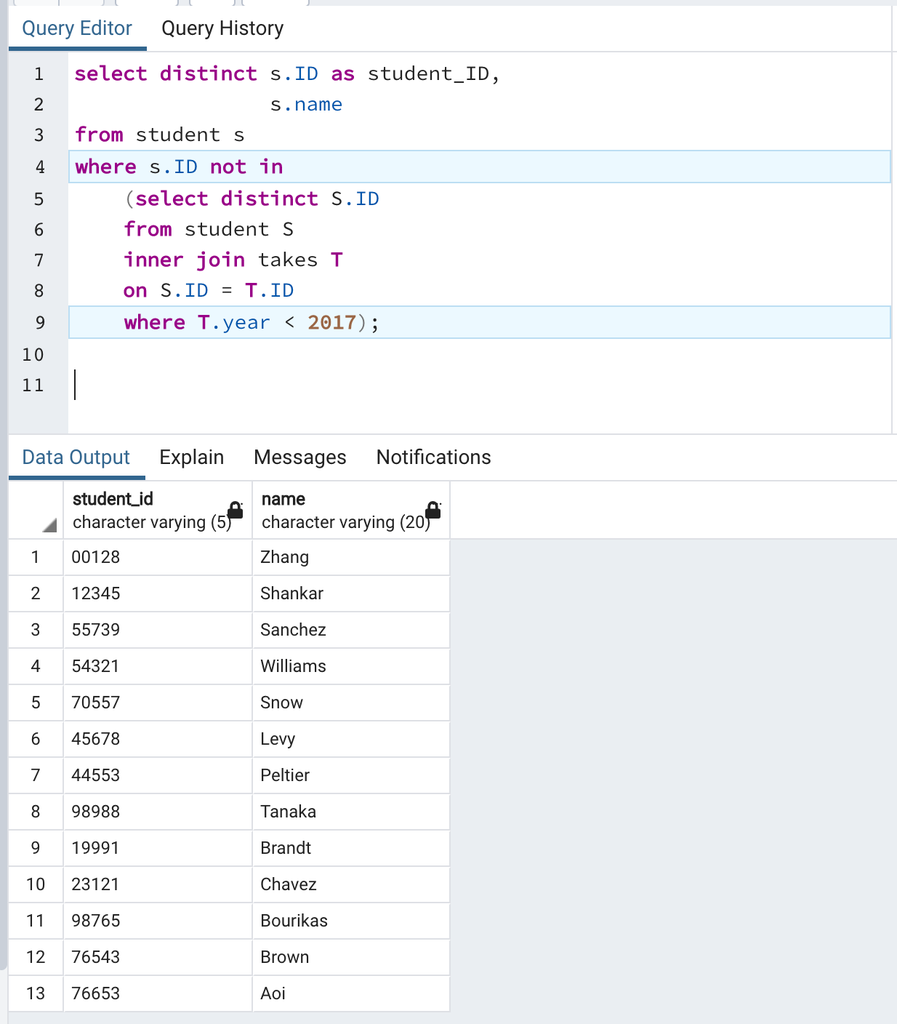

## 3.4 For each department, find the maximum salary of instructors in that department. You may assume that every department has at least one instructor.

```sql
select dept_name, max(I.salary) as maximum_salary
from instructor I
group by dept_name
```

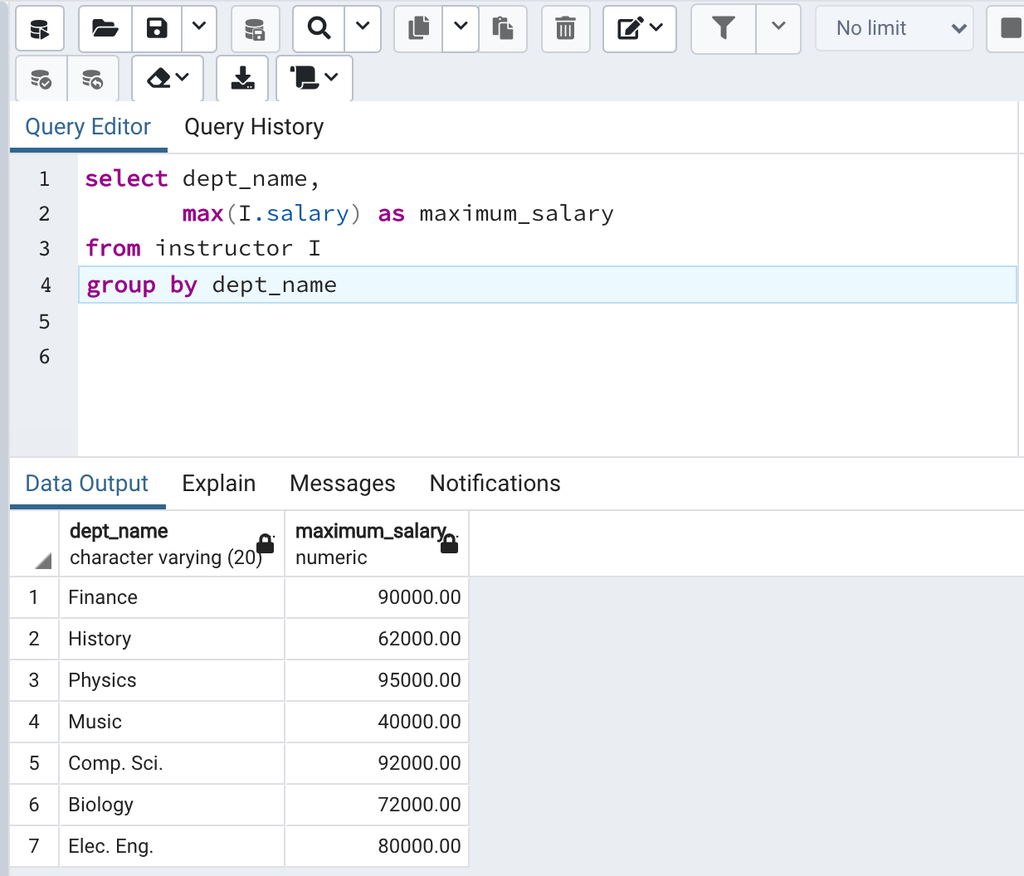

## 3.5 Find the lowest, across all departments, of the per-department maximum salary computed by the preceding query.

```sql
select max(I.salary) as maximum_salary
from instructor I
group by dept_name
order by maximum_salary
limit 1
```

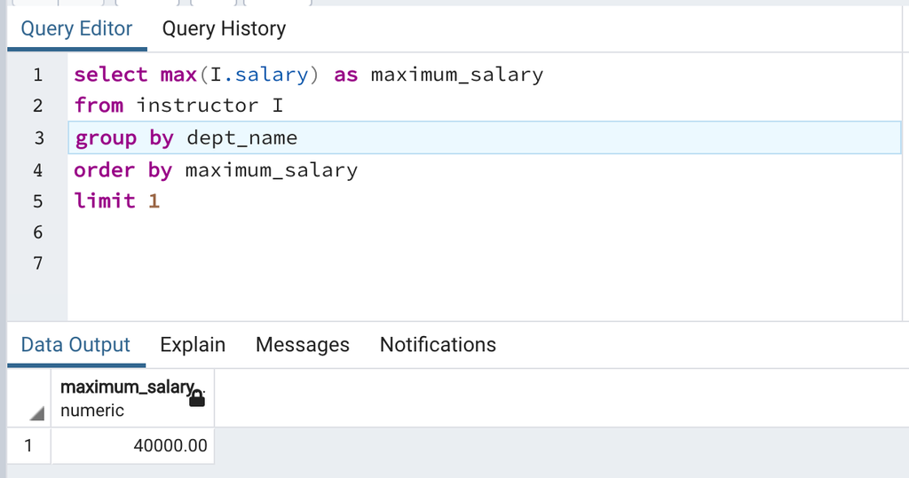

## 3.6 Add names to the list

```sql
select dept_name,
max(I.salary) as maximum_salary
from instructor I
group by dept_name
order by maximum_salary
limit 1
```

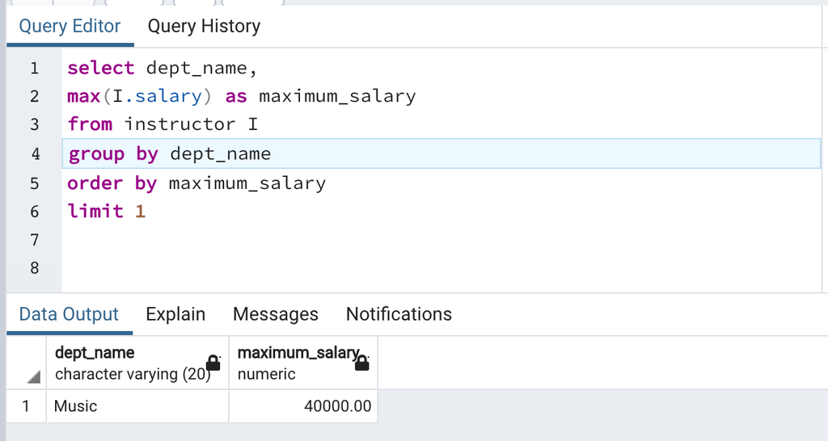

# 4 Find instructor (with name and ID) who has never given an A grade in any course she or he has taught. (Instructors who have never taught a course trivially satisfy this condition.)

```sql
select distinct I.name
from instructor I
inner join teaches Te
on I.ID = Te.ID
inner join section Se
on Te.course_id = Se.course_id
    and Te.sec_id = Se.sec_id
    and Te.semester = Se.semester
    and Te.year = Se.year
inner join takes Ta
on Ta.course_id = Se.course_id
    and Ta.sec_id = Se.sec_id
    and Ta.semester = Se.semester
    and Ta.year = Se.year
where Ta.grade != 'A'
```

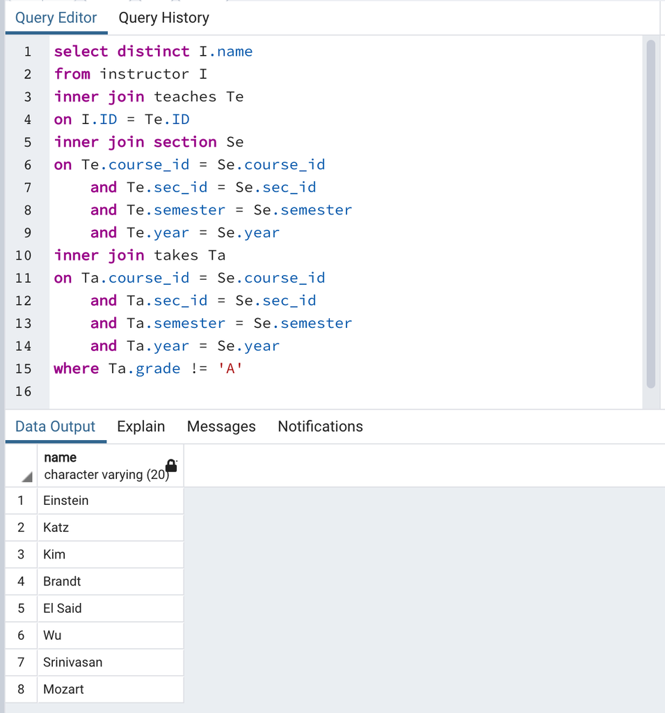

# 5 Write SQL query to find the number of students in each section. The result columns should appear in the order “courseid, secid, year, semester, num”. You do not need to output sections with 0 students.

```sql
select distinct Se.course_id, Se.sec_id,
        Se.year, Se.semester,
        count(S.ID) as number_of_students
from section Se
inner join takes Ta
on Ta.course_id = Se.course_id
    and Ta.sec_id = Se.sec_id
    and Ta.semester = Se.semester
    and Ta.year = Se.year
inner join Student S
on Ta.ID = S.ID
group by (Se.course_id, Se.sec_id, Se.year, Se.semester)
```

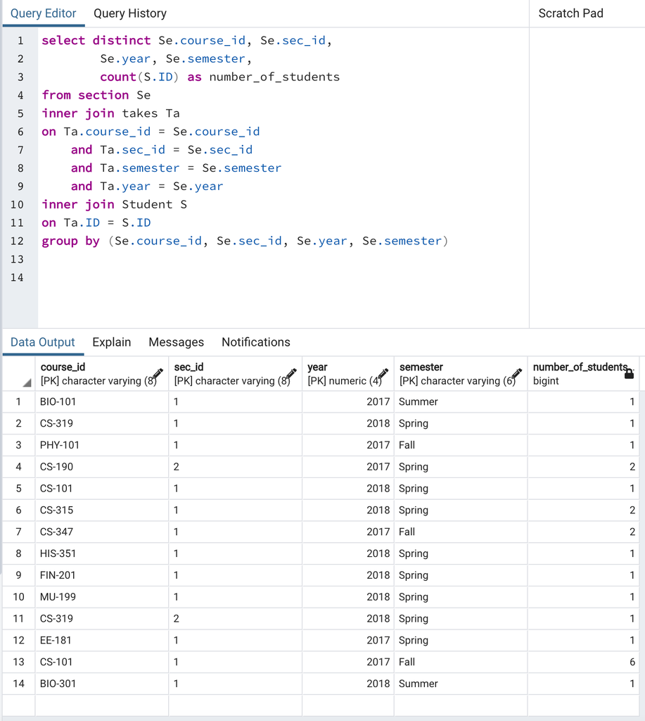